# L13 Presentation

Data Visualization (STAT 302)

Author

INSTRUCTIONS

## Overview

Quite often we want to share our visualizations and graphics as part of a presentation. In this lab we are going to learn the basics of building a Presentation with Quarto. Previously we used Quarto to create our homework documents because it allows use to interlace prose, code, and computational outputs seamlessly in a flexible, organized, neat, and dare I say, stylish manner. The same reasons should motivate us to use Quarto for building presentations.

## Readings & Resources

Look through the [Presentation Gallery](https://quarto.org/docs/gallery/#presentations) to get a sense of how you can use Quarto to create presentations.

Students should read through the following

- [Presentation Gallery](https://quarto.org/docs/gallery/#presentations)
- [Presentations](https://quarto.org/docs/presentations/)
- [Revealjs](https://quarto.org/docs/presentations/) (Reveal Basics, Presenting Slides)

**Tip**

A good chunk of the reading is dedicated to showing the code and tools needed to get started. You should skim the reading to get a sense of what you can do and bookmark them for future reference.

Other advanced resources for building presentations with Quarto:

- [Advanced Reveal](https://quarto.org/docs/presentations/revealjs/advanced.html)
- [Reveal Themes](https://quarto.org/docs/presentations/revealjs/themes.html)
- [Revealjs Options](https://quarto.org/docs/reference/formats/presentations/revealjs.html)

## Exercise

### Instructions

Build a short revealjs presentation using Quarto. The goal of this is for you to learn how to build a presentation and try out different tools. Meaning we don’t really care about the content in the presentation. We care about seeing you implementing and testing out options and features.

The slides do not have to form a coherent story so do yourself a favor and don’t worry about the content. If you want some coherence then think about making a set of slides about your favorite/least favorite sports team, some silly topic like dead memes, some hobby/interest that you have, or whatever you feel like.

Some basic things that **MUST** be followed:

- At least 4 total slides
- Slides must be numbered
- A slide with code and a graph (maybe a slide that shows a plot you’ve made for earlier labs)
- Implement line highlighting in a code block at least once
- At least 1 page that includes an image (maybe your favorite comic, meme, or animal)
- At least 1 slide implementing either multiple columns or tabsets
- Choose at least 4 other features to try (welcome to try more)

Try and have some fun with it.

### How to get started

Start by creating a directory for your presentation using our standard naming convention (`Lastname_Firstname_L13`). Where you locate this directory is up to you, but as you see in the image below I placed mine in `stat-302/presentations/`.

[figure not shown]

Next start a new project and set the existing directory `Lastname_Firstname_L13` as project home.

Once you have the new project set up it should have the name `Lastname_Firstname_L13` in the top right corner — see example below.

[figure not shown]

Now start a new **Quarto Presentation** either by going to **File > New File > Quarto Presentation** or by clicking the new document icon (top left in RStudio) and selecting **Quarto Presentation**.

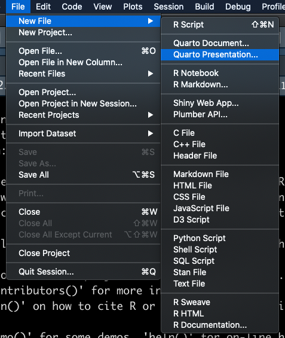

[figure not shown]

Follow the prompts and start building your presentations.

As you build you presentation think about file structure. If you have data you are using you should have a `data/` subdirectory. If you have image to include you should have an `image/` subdirectory.

Once you are done building your presentation then zip up/compress the project directory (`Lastname_Firstname_L13`) for submission. Meaning you should be submitting `Lastname_Firstname.zip` which should contain everything needed to see your presentation.

## Challenge

**Important**

Not required, but hope you try.

Try to publish your presentation on a free hosting site like [Quarto Pub](https://quartopub.com/). Read about how to publish your presentation here: [Publishing](https://quarto.org/docs/publishing/quarto-pub.html).

If you complete this challenge, then please place a link to your presentation in the comments section of your submission for this lab on Canvas.